# Demo 1 | Learning the Data Generating Process

Peter Kedron, Emily Zhou

2026-09-18

# 1. Setting Up the Data-Generating Process

A **data-generating process (DGP)** describes the underlying process that could have produced the observations we see. In this demonstration, we construct a deliberately simple hypothetical world. Every Vermont county has exactly the same underlying probability of cancer, but counties have different population sizes. This lets us ask an important question:

> If the underlying risk is identical everywhere, will the observed geographic pattern also look identical everywhere?

We begin by loading the Vermont county boundaries that will provide the spatial structure for the demonstration.

```r
vt_geom <- st_read("vt_county.geojson") %>%
  st_transform(32145) %>%
  st_make_valid() %>%
  st_simplify(dTolerance = 0.001)
```

Next, we assign each county a hypothetical population. The population sizes intentionally vary substantially across counties. Some counties have only 10 or 15 hypothetical residents, while others have 100 or 150. These differences will become important because rates calculated from small populations tend to be more variable.

```r
vt_pop <- tibble(
  CNTYNAME = c("ADDISON", "BENNINGTON", "CALEDONIA", "CHITTENDEN", "ESSEX", "FRANKLIN", "GRAND ISLE", "LAMOILLE", "ORANGE", "ORLEANS", "RUTLAND", "WASHINGTON", "WINDHAM", "WINDSOR"),
  population = c(15, 30, 20, 150, 10, 75, 12, 25, 20, 15, 100, 80, 50, 60))
vt_geom <- vt_geom %>%
  left_join(vt_pop, by = "CNTYNAME")
```

The resulting population distribution is shown below.

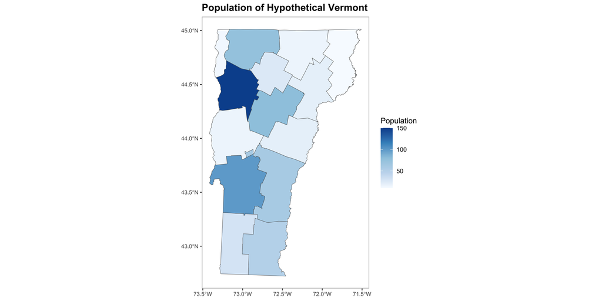

```r
ggplot(vt_geom) +
  geom_sf(aes(fill = population)) +
  scale_fill_gradientn(
    colors = continuous_palette,
    name = "Population",
    labels = scales::label_number()) +
  labs(title = "Population of Hypothetical Vermont") +
  themeClean
```

# 2. One Possible Realization

We now define the underlying cancer risk. For simplicity, every person in every county has the same probability of developing cancer:

$$P(\text{cancer}) = \frac{1}{6}$$

There is therefore **no true geographic variation in cancer risk** in our hypothetical world. For each county, we use a binomial process to generate the number of cancer cases based on its population size. A binomial process is appropriate because each individual either develops cancer or does not, and the probability of developing cancer is the same for everyone. For those who are not familiar, the binomial process is a standard statistical model for generating counts of successes (in this case, cancer cases) from a fixed number of trials (the population) with a constant probability of success (the underlying risk). We then calculate the observed cancer rate.

```r
true_risk <- 1 / 6
set.seed(172)

vt_sim1 <- vt_geom %>%
  mutate(
    true_risk = true_risk,
    # binomial process to generate observed cases
    cases = rbinom(n = n(), size = population, prob = true_risk),
    observed_rate = cases / population)
```

Even though the underlying probability is identical everywhere, the number of observed cases is partly determined by chance. The map below shows what one realization of this process might look like.

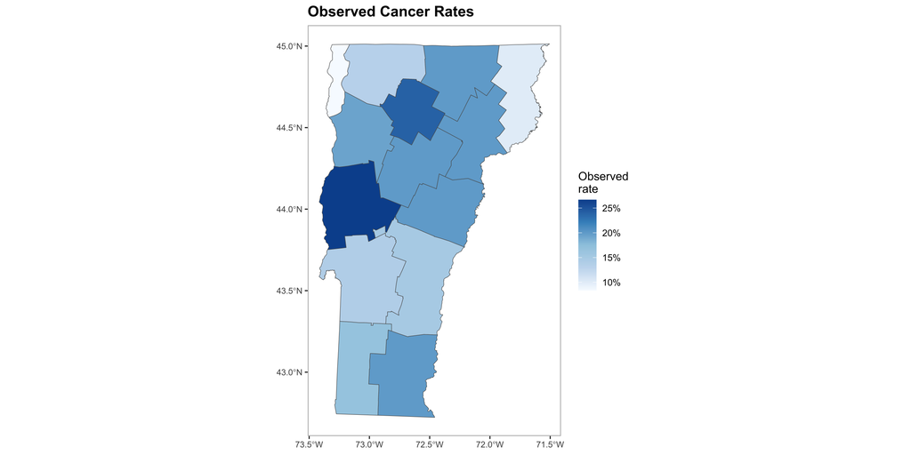

```r
ggplot(vt_sim1) +
  geom_sf(aes(fill = observed_rate)) +
  scale_fill_gradientn(
    colors = continuous_palette,
    labels = scales::label_percent(accuracy = 1),
    name = "Observed\nrate") +
  labs(title = "Observed Cancer Rates") +
  themeClean
```

At first glance, the map appears to contain geographic differences in cancer rates. However, we know how the data were generated. Every county has exactly the same underlying risk. The apparent spatial pattern is therefore produced by **sampling variability**, not by differences in the underlying process.

# 3. Same Process, Different Map

A data-generating process does not produce only one possible dataset. If we repeat exactly the same process, keeping the populations and underlying risk unchanged, we can obtain a different set of observed cancer rates.

```r
set.seed(173)

vt_sim2 <- vt_geom %>%
  mutate(
    true_risk = true_risk,
    cases = rbinom(n = n(), size = population, prob = true_risk),
    observed_rate = cases / population)
```

To compare the two simulations fairly, we calculate a common range of observed rates and use the same map scale for both.

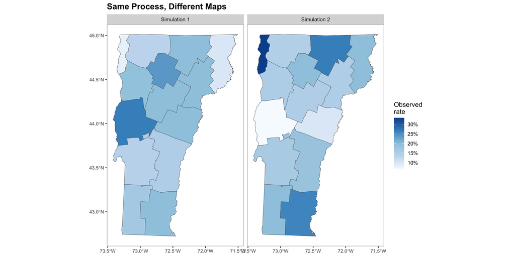

```r
rate_limits <- range(c(vt_sim1$observed_rate, vt_sim2$observed_rate), na.rm = TRUE)

sim_compare <- bind_rows(
  vt_sim1 %>% mutate(world = "Simulation 1"),
  vt_sim2 %>% mutate(world = "Simulation 2"))

ggplot(sim_compare) +
  geom_sf(aes(fill = observed_rate)) +
  scale_fill_gradientn(
    colors = continuous_palette,
    limits = rate_limits,
    oob = scales::squish,
    labels = scales::label_percent(accuracy = 1),
    name = "Observed\nrate") +
  facet_wrap(~ world) +
  labs(title = "Same Process, Different Maps") +
  themeClean
```

The two maps were generated using the same counties, the same population sizes, the same underlying cancer risk, and the same statistical process. Yet the resulting spatial patterns are different. This illustrates a central idea of the demonstration:

> **An observed spatial pattern is only one possible realization of an underlying data-generating process.**

# 4. Repeating the Process 100 Times

Two simulations show that different outcomes are possible, but we can make the idea more visible by repeating the experiment many times. We therefore simulate 100 hypothetical worlds, each generated from exactly the same underlying process.

```r
set.seed(172)

n_sims <- 100
true_risk <- 1 / 6

sim_100 <- expand_grid(
  simulation = 1:n_sims,
  CNTYNAME = vt_geom$CNTYNAME) %>%
  left_join(vt_geom %>% st_drop_geometry() %>% select(CNTYNAME, population),
    by = "CNTYNAME") %>%
  mutate(cases = rbinom(
      n = n(),
      size = population,
      prob = true_risk),
    observed_rate = cases / population)
```

For each county, we can now examine the distribution of observed cancer rates across the 100 simulations. The dashed line represents the true underlying cancer risk of $1/6$.

```r
sim_100 <- sim_100 %>%
  mutate(
    county_label = paste0(
      str_to_title(CNTYNAME),
      "\nPopulation = ", population),
    county_label = fct_reorder(county_label, population),
    pop_group = case_when(
      population <= 20 ~ "Small",
      population <= 60 ~ "Medium",
      TRUE ~ "Large"))

ggplot(sim_100, aes(x = observed_rate, fill = pop_group, group = CNTYNAME)) +
  geom_histogram(binwidth = 0.025,
    boundary = 0,
    color = "white",
    linewidth = 0.2) +
  geom_vline(
    xintercept = true_risk,
    linetype = "dashed",
    linewidth = 0.5) +
  scale_fill_manual(values = c(
      "Small" = categorical_palette[4],
      "Medium" = categorical_palette[2],
      "Large" = categorical_palette[1]),
    name = "Population group") +
  scale_x_continuous(labels = scales::label_percent()) +
  facet_wrap(~ county_label, ncol = 4) +
  labs(
    title = "100 Possible Outcomes from the Same Data-Generating Process",
    subtitle = "Counties are ordered from smallest to largest population",
    x = "Observed rate",
    y = "Number of simulations") +
  themeGrid
```

[figure not shown]

# 5. What Does the Simulation Tell Us

Several patterns should now be visible.Counties with **small populations** produce much wider distributions of observed rates. Their observed values can sometimes be extremely high or extremely low simply because only a small number of individuals contribute to the calculation. Counties with **larger populations** tend to produce observed rates that remain much closer to the true underlying probability.

In other words,

$$\text{same underlying risk} \neq \text{same observed rate}$$

and the amount of variation we observe depends partly on the amount of information available.

This distinction is important when interpreting spatial data. A map shows us an observed spatial pattern. Our scientific question, however, often concerns the process that generated that pattern. A cluster, hotspot, or extreme rate may reflect a meaningful geographic process, but it may also arise from random variation, unequal sample sizes, measurement processes, or other features of the data-generating process.